# Gait Analysis

### Statistiche

Il valore della derivata in un punto corrisponde alla velocità in quel punto. Ciò significa che le valli rappresentano il punto in cui il piede è fermo.

Queste informazioni ci permettono di calcolare delle statistiche sulla camminata del paziente e della persona sana: calcolando la distanza tra una valle e l'altra otteniamo il numero di frame necessari all'individuo per fare un passo. Sapendo che il campionamento del segnale è stato effettuato con una frequenza pari a 25 fps, possiamo ottenere il tempo impiegato per effettuare il passo.

```python
def time(valleys):
    time = []
    for i in range(0,len(valleys)-1,2):
        time.append((valleys[i+1]-valleys[i])/25)
    return np.around(np.mean(time), 3)
```

```python
print("Tempo medio impiegato dalla persona sana per effettuare un passo: ", time(person_valleys), "s")
print("Tempo medio impiegato dal paziente per effettuare un passo: ", time(patient_valleys), "s")
```

```
Tempo medio impiegato dalla persona sana per effettuare un passo:  1.18 s
Tempo medio impiegato dal paziente per effettuare un passo:  1.7 s
```

Analogamente possiamo analizzare la lunghezza del passo dei due individui

```python
def length(f, valleys):
    length = []
    for i in range(0,len(valleys)-1,2):
        length.append((f[valleys[i]]-f[valleys[i+1]])/10)
    return np.around(np.mean(length), 3)
```

```python
print("Lunghezza media di un passo della persona sana: ", length(filt_person, person_valleys), "cm")
print("Lunghezza media di un passo del paziente: ", length(filt_patient, patient_valleys), "cm")
```

```
Lunghezza media di un passo della persona sana:  74.709 cm
Lunghezza media di un passo del paziente:  43.747 cm
```

Un'altra statistica confrontabile riguarda il numero di passi nel segnale. Questa informazione può essere derivata dal numero di picchi trovati.

```python
print("Numero di passi persona sana: ", len(person_peaks))
print("Numero di passi paziente: ", len(patient_peaks))
```

```
Numero di passi persona sana:  2
Numero di passi paziente:  2
```

In questo caso il numero di passi del paziente e della persona sana coincidono, come possiamo osservare dai grafici precedentemente tracciati.

Possiamo ripetere il procedimento analizzando le statistiche per diversi individui e confrontare i risultati ottenuti.

Persona 0

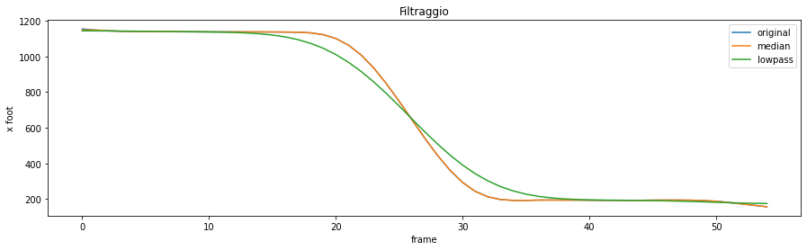

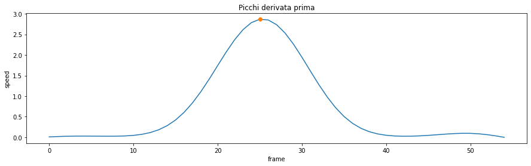

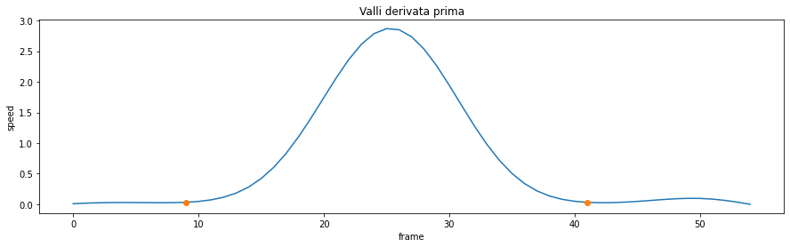

Persona 1

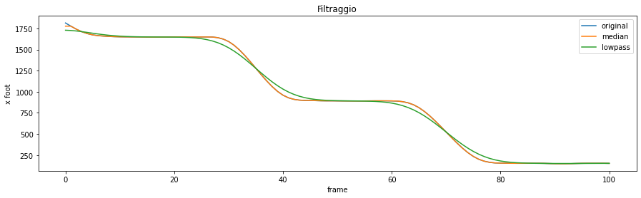

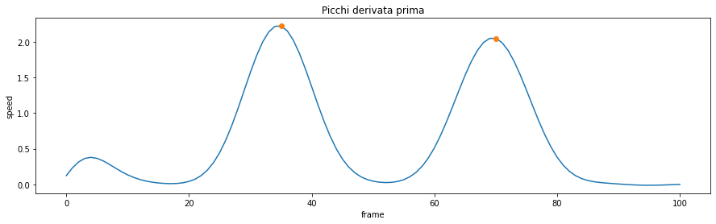

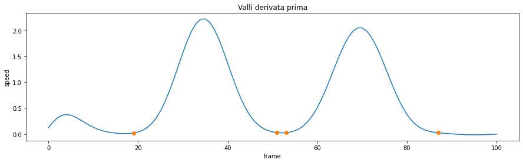

Persona 2

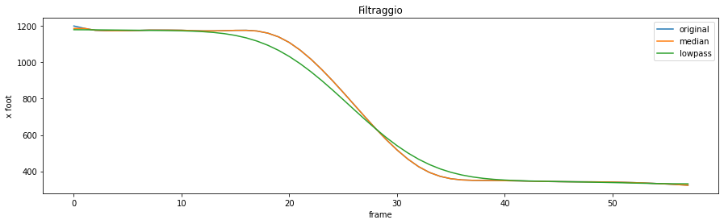

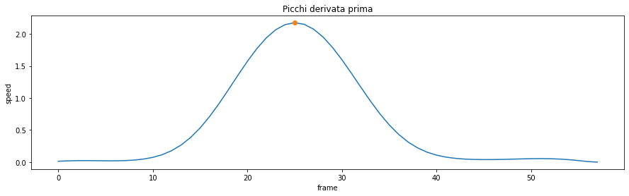

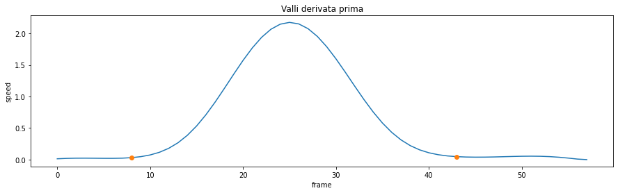

Persona 3

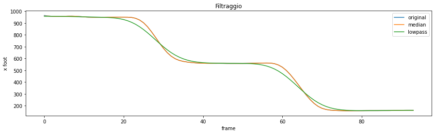

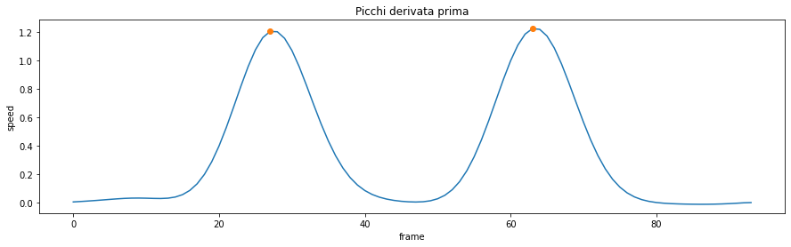

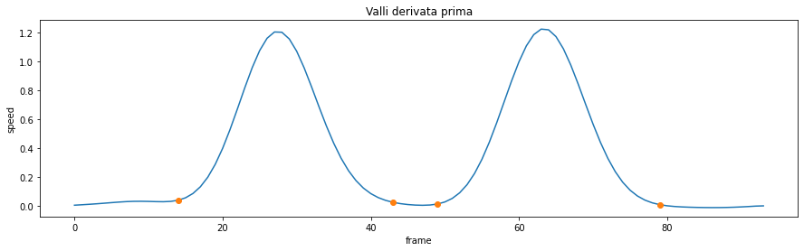

Persona 4

[3 more figures not shown]

```python
people_times = []
people_length = []
people_steps = []

for i,person in enumerate(data_people):
    display(Markdown(f'### Persona {i}' ))
    f_person = removeNan(person[:, serie])
    filt_person = median_filter(f_person, 4)
    f_prime = derivative(filt_person)
    person_peaks = peaks(f_prime)
    person_valleys = valleys(f_prime, person_peaks)
    people_times.append(time(person_valleys))
    people_length.append(length(filt_person, person_valleys))
    people_steps.append(len(person_peaks))
    print('\n')
```

Paziente 0

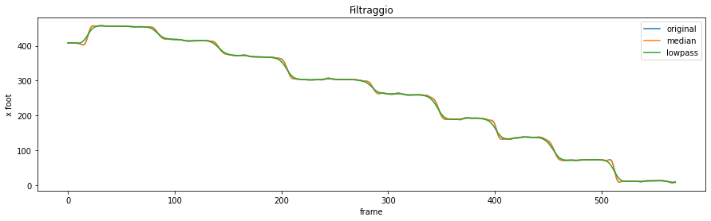

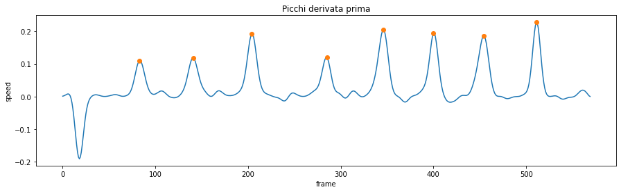

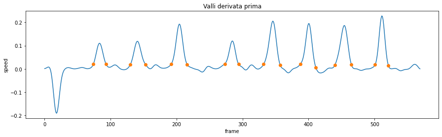

Paziente 1

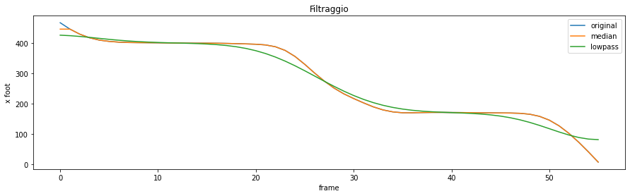

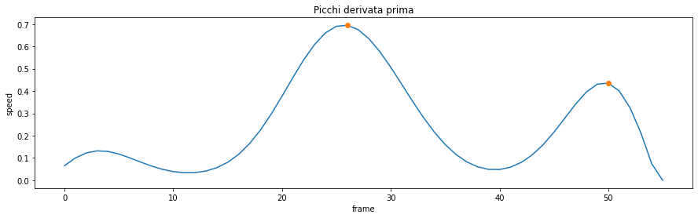

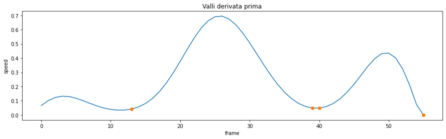

Paziente 2

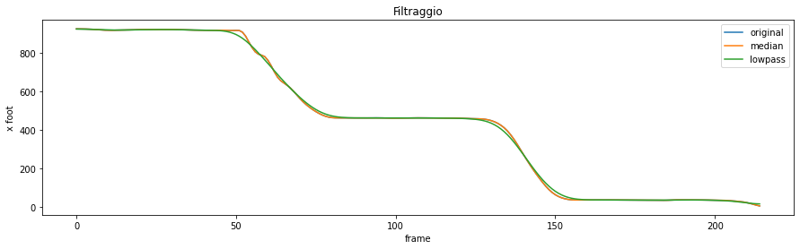

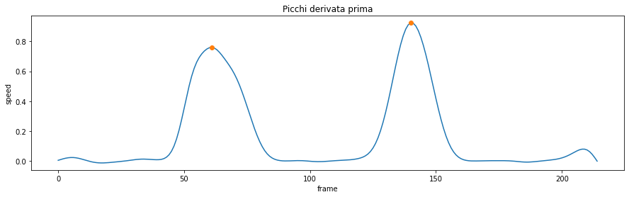

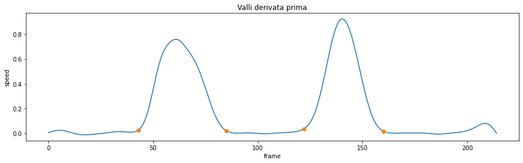

Paziente 3

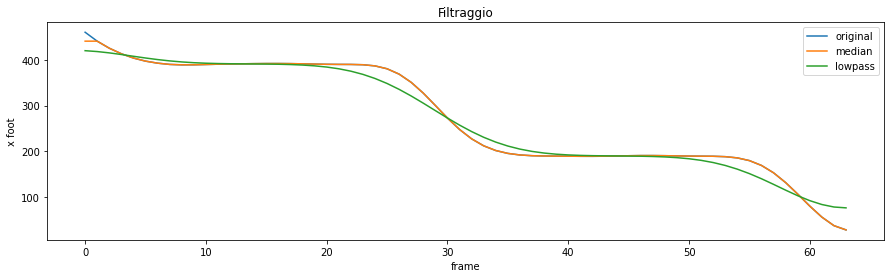

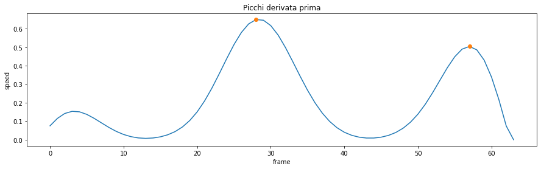

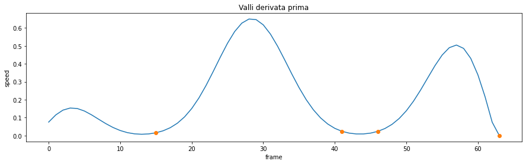

Paziente 4

[9 more figures not shown]

```python
patients_times = []
patients_length = []
patients_steps = []

for i,patient in enumerate(data_patients):
    display(Markdown(f'### Paziente {i}'))
    f_patient = removeNan(patient[:, serie])
    filt_patient = median_filter(f_patient, 4)
    f_prime = derivative(filt_patient)
    patient_peaks = peaks(f_prime)
    patient_valleys = valleys(f_prime, patient_peaks)
    patients_times.append(time(patient_valleys))
    patients_length.append(length(filt_patient, patient_valleys))
    patients_steps.append(len(patient_peaks))
    print('\n')
```

Andiamo a stampare e confrontare i dati ottenuti, riguardanti il passo di pazienti e persone sane

**Lunghezza passo**

```python
print('Lunghezza passi persone sane', people_length)
print('Lungezza media passi persone sane', np.round(np.mean(people_length),2),'cm \n')

print('Lunghezza passi pazienti', patients_length)
print('Lunghezza media passi pazienti', np.round(np.mean(patients_length),2), 'cm \n')
```

```
Lunghezza passi persone sane [94.476, 74.758, 83.01, 39.419, 26.832]
Lungezza media passi persone sane 63.7 cm

Lunghezza passi pazienti [5.266, 15.841, 43.804, 15.603, 27.19, 57.051, 17.659]
Lunghezza media passi pazienti 26.06 cm
```

**Tempo per effettuare un passo**

```python
print('Tempo passo persone sane', people_times)
print('Tempo medio passo persone sane', np.round(np.mean(people_times),2),'s \n')

print('Tempo passo pazienti', patients_times)
print('Tempo medio passo pazienti', np.round(np.mean(patients_times),2),'s \n')
```

```
Tempo passo persone sane [1.28, 1.32, 1.4, 1.18, 1.2]
Tempo medio passo persone sane 1.28 s

Tempo passo pazienti [0.9, 0.82, 1.6, 0.86, 1.333, 1.44, 1.1]
Tempo medio passo pazienti 1.15 s
```

**Velocità di un passo**

```python
people_speed = np.round(np.divide(people_length,people_times)/27.778,3)
print('Velocità passo persona sana',people_speed)
print('Velocità media passo persone sane', np.round(np.mean(people_speed),2), "km/h \n")

patients_speed = np.round(np.divide(patients_length,patients_times)/27.778,3)
print('Velocità passo paziente', patients_speed)
print('Velocità media passo pazienti', np.round(np.mean(patients_speed),2), "km/h \n")
```

```
Velocità passo persona sana [2.657 2.039 2.135 1.203 0.805]
Velocità media passo persone sane 1.77 km/h

Velocità passo paziente [0.211 0.695 0.986 0.653 0.734 1.426 0.578]
Velocità media passo pazienti 0.75 km/h
```

Possiamo notare come mediamente i pazienti impieghino lo stesso tempo degli individui sani ad effettuare un passo, ma che effettuino passi molto più corti. Questo viene ulteriormente messo in risalto dalla velocità del passo, che risulta essere inferiore per i pazienti.

**Numero di passi**

```python
print('Numero di passi persone sane', people_steps)
print('Numero medio di passi persone sane', np.mean(people_steps), '\n')

print('Numero di passi pazienti', patients_steps)
print('Numero medio di passi pazienti', np.round(np.mean(patients_steps),2))
```

```
Numero di passi persone sane [1, 2, 1, 2, 2]
Numero medio di passi persone sane 1.6

Numero di passi pazienti [8, 2, 2, 2, 3, 1, 2]
Numero medio di passi pazienti 2.86
```

Anche il numero di passi risulta essere maggiore per i pazienti, soprattutto per il paziente numero 0. Questo potrebbe essere dovuto dal fatto di una maggiore incertezza e una minore mobilità nella gamba dovuti ai disturbi neuromotori.

## Conclusioni

Dalle analisi effettuate possiamo trarre le seguenti conclusioni:

- L'uso di animazioni per la rappresentazione di serie temporali permette di ricostruire il movimento della gamba e di effettuare alcune osservazioni che possono rivelarsi utili in una successiva fase di analisi più specifica.
- La fase di analisi vera e propria deve essere preceduta da una fase di filtraggio e pulizia dei dati accurata al fine di garantire la correttezza dell'analisi stessa, poiché l'applicazione di diverse trasformazioni ai segnali può portare all'accentuamento di eventuali fenomeni di rumore e discontinuità (ad esempio con il calcolo delle differenze finite).
- L'analisi delle derivate delle serie temporali permette di calcolare numerose statistche sulla camminata degli individui. La conoscenza delle statistiche di pazienti e di persone sane permette di mettere a confronto in modo oggettivo la camminata e il suo andamento. In ambito medico questo significa poter effettuare diagnosi precoci e più dettagliate di eventuali disturbi neuromotori.